# NECorr: ranking the genes of a network for one condition

Christophe Liseron-Monfils

NECorr ranks the genes of a molecular network for their importance in one condition, using expression data measured across several conditions.

# Example data

The package ships a small simulated data set: a regulatory network of 12 transcription factors, and expression of 120 genes in four conditions. `Gene001` and its targets are co-expressed and induced in flower.

```r
data(necorr_example)
head(necorr_example$networkFile, 3)
```

```
#>    source  target
#> 1 Gene001 Gene015
#> 2 Gene001 Gene068
#> 3 Gene001 Gene043
```

```r
necorr_example$expression[1:3, 1:5]
```

```
#>          GeneID root_1 root_2 root_3 root_4
#> Gene001 Gene001  7.807  6.132  7.048  5.668
#> Gene002 Gene002  6.770  7.667  5.697  8.141
#> Gene003 Gene003  8.397  5.848  6.630  5.017
```

```r
head(necorr_example$meta_data, 3)
```

```
#>   SampleID Condition
#> 1   root_1      root
#> 2   root_2      root
#> 3   root_3      root
```

```r
head(necorr_example$description.file, 3)
```

```
#>   gene_id Category             Description
#> 1 Gene001       TF Description for Gene001
#> 2 Gene002       TF Description for Gene002
#> 3 Gene003       TF Description for Gene003
```

The same data are available as text files, and `NECorr()` accepts file paths:

```r
list.files(system.file("extdata", package = "NECorr"), pattern = "^example_")
```

```
#> [1] "example_expression.txt"       "example_gene_description.txt"
#> [3] "example_network.txt"          "example_sample_metadata.txt"
```

# Running NECorr

```r
res <- NECorr(
  networkFile      = necorr_example$networkFile,
  expression       = necorr_example$expression,
  description.file = necorr_example$description.file,
  meta_data        = necorr_example$meta_data,
  condition        = "flower",
  method           = "GCC",
  permutation      = 200,
  directed         = TRUE,
  n_null           = 50,
  visualize        = FALSE,
  save_results     = FALSE,
  verbose          = FALSE
)
```

`method` can be one or several of `"GCC"` (Gini), `"PCC"` (Pearson), `"SCC"` (Spearman) and `"KCC"` (Kendall). `permutation` is the number of permutations for the GCC p-value. `n_null` adds an empirical p-value per gene.

# Results

Ranked genes. `Gene001` and its targets are expected at the top.

```r
head(res$necorrHub_nodes, 8)
```

```
#>      Gene     Score p_empirical       FDR
#> 1 Gene001 0.9492050  0.01990050 0.9373347
#> 2 Gene003 0.8910341  0.11940299 0.9373347
#> 3 Gene002 0.8646235  0.18905473 0.9564480
#> 4 Gene012 0.8041165  0.34413965 0.9957577
#> 5 Gene011 0.6878516  0.54364090 0.9987961
#> 6 Gene068 0.6641786  0.01977084 0.9373347
#> 7 Gene044 0.6608494  0.02920692 0.9373347
#> 8 Gene092 0.6575033  0.03909234 0.9373347
```

The criteria behind the score, each as a rank between 0 and 1, and their weights:

```r
round(head(res$hub.m.param[res$necorrHub_nodes$Gene, ], 5), 2)
```

```
#>           DE Degree
#> Gene001 1.00   0.90
#> Gene003 0.88   0.90
#> Gene002 0.81   0.92
#> Gene012 0.67   0.96
#> Gene011 0.49   0.98
```

```r
round(res$criterion_weights, 3)
```

```
#>     DE Degree
#>    0.5    0.5
```

Candidate regulators, ordered by their own score. The enrichment of top-scoring genes among their targets is shown alongside.

```r
head(res$necorrReg[, c("Gene", "role", "n_partners", "n_hub_partners", "fold_enrichment", "FDR")], 5)
```

```
#>      Gene      role n_partners n_hub_partners fold_enrichment        FDR
#> 1 Gene001 regulator         10              4       4.4444444 0.06244292
#> 2 Gene003 regulator         10              1       1.1111111 1.00000000
#> 3 Gene002 regulator         12              1       0.9259259 1.00000000
#> 4 Gene012 regulator         15              1       0.7407407 1.00000000
#> 5 Gene011 regulator         18              2       1.2345679 1.00000000
```

Top-ranked edges. `percentile` is a rank among all edges, not a p-value.

```r
head(res$necorrEdges, 5)
```

```
#>     sourceIDs targetIDs edge_score percentile
#> 159   Gene011   Gene001  0.8185283  1.0000000
#> 2     Gene001   Gene068  0.8066918  0.9942529
#> 5     Gene001   Gene044  0.8050272  0.9885057
#> 10    Gene001   Gene092  0.8033541  0.9827586
#> 6     Gene001   Gene102  0.8016725  0.9770115
```

What was run:

```r
str(res$settings[c("weights", "aggregation", "direction", "scaling", "degree_type", "directed")])
```

```
#> List of 6
#>  $ weights    : chr "equal"
#>  $ aggregation: chr "product"
#>  $ direction  : chr "up"
#>  $ scaling    : chr "rank"
#>  $ degree_type: chr "targets"
#>  $ directed   : logi TRUE
```

# Criteria, weights and aggregation

By default the score is the rank product of two criteria. `DE` is the differential expression of the condition against the mean of the other conditions, counted only when the gene is up-regulated (`direction = "up"`). `Degree` is the number of targets of the gene in a directed network, and the number of partners in an undirected one (`degree_type`). Each is turned into a rank divided by the number of genes and the score is their geometric mean, so there is no weight to choose and up-regulated regulators with many targets come first. This default was selected on human cancer cell lines, where genome-wide CRISPR screens give a complete ground truth.

Four further criteria can be added. `TS` measures how consistently the gene is higher in the condition than in every other condition. `Coexpr` counts the network partners that are strongly co-expressed with the gene and compares the count with random partners drawn as in a degree-preserving randomisation of the network. `CondCoexpr` is `Coexpr` restricted to the part of the correlation that comes from the samples of the condition. `Bridging` is betweenness centrality beyond what degree predicts.

A ranking that uses only the wiring and the expression, with weights from the Analytic Hierarchy Process (AHP):

```r
c3 <- c("Coexpr", "TS", "CondCoexpr")
A <- necorr_ahp_matrix(c3, preset = "wiring")
round(A, 2)
```

```
#>            Coexpr  TS CondCoexpr
#> Coexpr        1.0 1.0          2
#> TS            1.0 1.0          2
#> CondCoexpr    0.5 0.5          1
```

```r
ahp <- ahp_weights(A)
round(ahp$weights, 2)
```

```
#>     Coexpr         TS CondCoexpr
#>        0.4        0.4        0.2
```

```r
ahp$CR   # consistency ratio, should be below 0.1
```

```
#> [1] 0
```

```r
res_wiring <- NECorr(
  necorr_example$networkFile, necorr_example$expression, necorr_example$description.file,
  "flower", necorr_example$meta_data, method = "PCC", permutation = 0,
  criteria = c3, aggregation = "product", scaling = "softcap", weights = A,
  directed = TRUE, visualize = FALSE, save_results = FALSE, verbose = FALSE)
round(res_wiring$criterion_weights, 2)
```

```
#>     Coexpr CondCoexpr         TS
#>        0.4        0.2        0.4
```

```r
head(res_wiring$coexpression_stats[order(-res_wiring$coexpression_stats$Coexpr), c("Gene", "k", "n_strong", "Coexpr", "CondCoexpr")], 3)
```

```
#>       Gene  k n_strong    Coexpr CondCoexpr
#> 1  Gene001 11       10 13.073403  13.073403
#> 47 Gene055  3        2  4.900770   4.900770
#> 52 Gene063  1        1  4.358899   4.358899
```

To use your own judgements, edit the matrix (keeping it reciprocal) and pass it as `weights`. Other options are `"critic"`, `"equal"`, `"entropy"`, or a named numeric vector. The criteria are combined by a weighted product by default; `aggregation = "sum"` gives the weighted sum.

```r
res_alt <- NECorr(
  necorr_example$networkFile, necorr_example$expression, necorr_example$description.file,
  "flower", necorr_example$meta_data, method = "PCC", permutation = 0,
  criteria = c("Coexpr", "TS", "CondCoexpr", "DE"), weights = "critic", aggregation = "sum",
  directed = TRUE, visualize = FALSE, save_results = FALSE, verbose = FALSE)
round(res_alt$criterion_weights, 3)
```

```
#>     Coexpr CondCoexpr         TS         DE
#>      0.256      0.253      0.232      0.259
```

```r
head(res_alt$necorrHub_nodes$Gene, 8)
```

```
#> [1] "Gene001" "Gene044" "Gene102" "Gene068" "Gene120" "Gene091" "Gene026"
#> [8] "Gene055"
```

# Plots and saved files

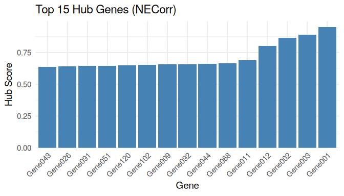

```r
plots <- visualize_necorr_results(res, top_n = 15)
plots$top_hubs_plot
```

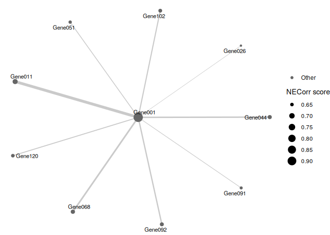

```r
plots$network_plot
```

With `save_results = TRUE` and an `output_dir`, `NECorr()` writes `necorrHub_nodes.csv`, `necorrReg.csv`, `necorrEdges.csv`, `coexpres.csv`, `hub.m.param.csv`, `netstat.csv` and `criterion_weights.csv`.

# Notes on use

- The network must be measured independently of the expression data. Do not use a co-expression network built from the same samples.
- Set `directed = FALSE` for protein-protein interaction networks. Genes in `necorrReg` are then reported as “associated”, not as regulators.
- Correlations are imprecise with fewer than about 8 to 10 samples.
- The default follows up-regulation and the number of targets, so only genes that are regulators in the network can reach the top of the list. Give the network with the regulator in the first column and `directed = TRUE`.
- The co-expression criteria need network edges that are reflected in the expression data, and they did not improve the ranking on the human benchmark.